# Chapter 9: ARIMA models

## 패키지 로드

```r
library(tidyverse)
library(fpp3)
library(tsibble)
library(tsibbledata)
library(feasts)
library(fable)
library(fabletools)
library(distributional)
library(latex2exp)
```

## ARIMA 모델

## ARIMA 모델

**ARIMA 모델은 시계열을 예측하는 또 하나의 접근 방법**이며 **데이터에 나타나는 자기상관(autocorrelation)을 표현하는데 목적**이 있음

ARIMA 모델을 소개하기에 앞서, **정상성(stationarity)**과 시계열의 **차분(differencing)**을 구하는 기법을 먼저 다뤄야 함

## 정상성과 차분

## 정상성과 차분

정상성(stationarity)을 나타내는 시계열의 특징은 해당 시계열이 **관측된 시간에 무관**

### 정상성을 띠지 않는 시계열의 특징

- 추세(trend)가 보임
- 계절성(seasonality)이 있음
- 분산이 시간에 따라 변화함

**추세와 계절성은 서로 다른 시간에 시계열의 값에 영향을 미침**

반면, **백색잡음(white noise)** 시계열은 정상성을 나타내는 시계열

- 언제 관찰하는지에 상관이 없고, 시간을 따른 어떤 시점에서도 동일하게 보임

## Non-stationary 시계열

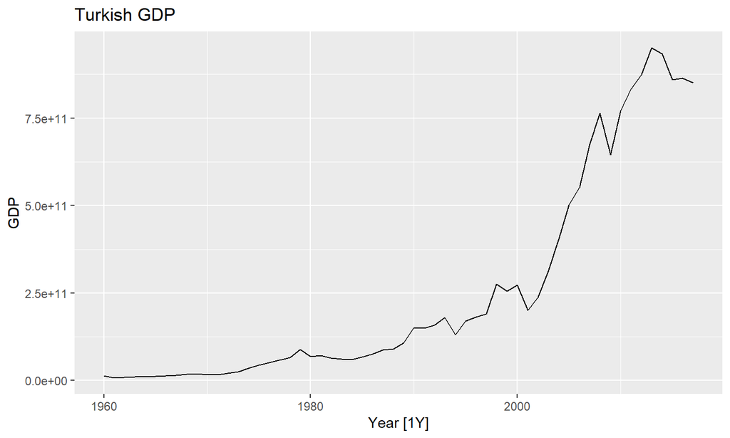

```r
global_economy %>%
  filter(Code == "TUR") %>%
  autoplot() +
  labs(title = "Turkish GDP")
```

## Non-stationary 시계열

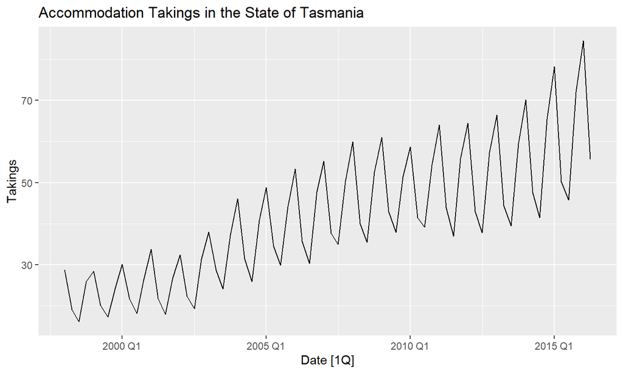

```r
aus_accommodation %>%
  filter(State == "Tasmania") %>%
  autoplot() +
  labs(title = "Accommodation Takings in the State of Tasmania")
```

## Stationary 시계열

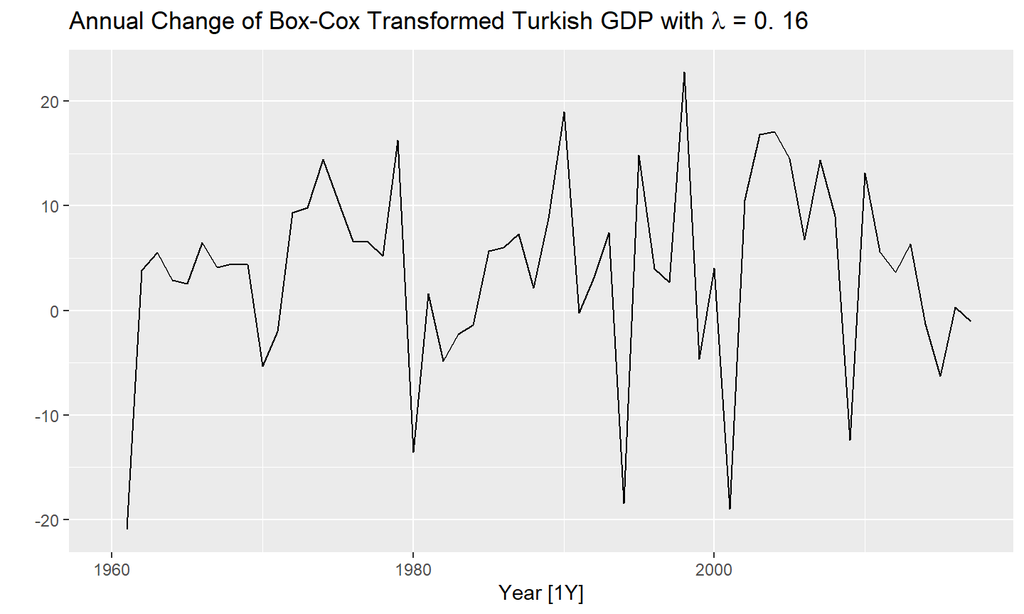

```r
global_economy %>% filter(Code == "TUR") %>%
  autoplot(difference(box_cox(GDP, lambda))) +
  labs(y = "", title = latex2exp::TeX(paste0(
         "Annual Change of Box-Cox Transformed Turkish GDP with $\\lambda$ = ",
         round(lambda,2))))
```

## **차분(differencing)**

### **차분이란**

연이은 관측치들의 **차이**를 계산하여 시계열을 **정상적으로 만듦**

- 시계열 수준의 변화를 제거하여 평균의 안정을 도모
- **추세나 계절성을 제거 혹은 감소시킴**
- ACF 그래프를 통해 정상성 변화를 시각적으로 확인 가능

## **차분(differencing)**

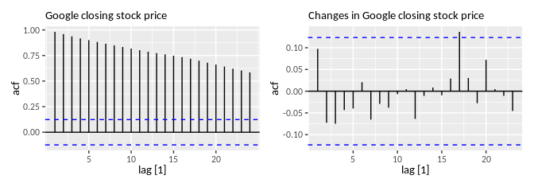

Figure 9.2: The ACF of the Google closing stock price in 2015 (left) and of the daily changes in Google closing stock price in 2015 (right).

차분을 구한 구글 주식 가격의 ACF는 단순히 백색잡음(white noise) 시계열처럼 보임.

## **차분(differencing)**

```r
google_stock %>% filter(year(Date) == 2015) %>%
  mutate(diff_close = difference(Close)) %>%
  features(diff_close, ljung_box, lag = 10)
```

```
$  # A tibble: 1 x 3
$    Symbol lb_stat lb_pvalue
$    <chr>    <dbl>     <dbl>
$  1 GOOG      7.91     0.637
```

융-박스(Ljung-Box)\(Q^*\) 통계 또한 (\(h=10\)에 대해서) 0.637의 p-value를 지니며, 이는 구글 주가의 일일 변동이 작일과 관련이 없는 무작위적임을 의미함.

## **차분(differencing)** - 확률보행 모델

시계열에서 연이은 관측값의 차이인 차분 시계열은 다음과 같이 나타낼 수 있다.

\[ y'_t = y_t - y_{t-1}. \]

차분을 구한 시계열이 백색잡음(white noise)이면, 원래 시계열은 다음과 같다.

\[ y_t - y_{t-1} = \varepsilon_t, \]

이를 정리하면 확률보행(random walk) 모델을 얻을 수 있다.

\[ y_t = y_{t-1} + \varepsilon_t. \]

## **차분(differencing)** - 확률보행 모델

확률보행(random walk) 모델은 금융이나 경제 데이터와 같은 정상성을 나타내지 않는 데이터를 다룰 때 사용됨

### 확률보행의 특징

- 긴 주기의 분명한 상향 또는 하향 추세.
- 갑작스럽고 예측 불가한 방향 변화

\[ {y_t = c + y_{t-1} + \varepsilon_t}\: . \]

한편 절편(drift)이 있는 확률보행과정은 상수항이 양수면 \(y_t\)는 위쪽 방향으로 이동하는 경향을, 음수면 \(y_t\)는 아래쪽으로 이동하는 경향이 나타남

## 2차 차분(Second-order differencing)

차분을 구한 데이터가 정상성을 띠지 않을 때 다음과 같이 **한 번 더 차분을 구하는 것**

\[ \begin{align*} y''_{t} &= y'_{t} - y'_{t - 1} \\ &= (y_t - y_{t-1}) - (y_{t-1}-y_{t-2})\\ &= y_t - 2y_{t-1} +y_{t-2}. \end{align*} \]

- ’원본데이터의 **변화’의 변화**를 모델링하는 것임
- **2차 차분을 넘어서는 차분을 구해야 하는 경우는 드뭄**

## 계절성 차분(Seasonal differencing)

계절성 차분(seasonal differencing)은 관측치(\(y_t\))와, 같은 계절의 이전 관측값(\(y_{t-m}\))과의 차이를 말함. 여기서 \(m\)은 계절의 개수

\[ y'_t = y_t - y_{t-m}, \]

계절성 차분을 구한 데이터가 백색잡음을 보이면, 다음과 같이 나타낼 수 있음

\[ y_t = y_{t-m}+\varepsilon_t. \]

## 단위근검정(Unit root tests)

차분을 보다 객관적으로 구하는 것이 필요할지 결정하기 위해 사용

- 단위근검정은 다양한 통계적 가설 검정들이 존재함
- 본 발제에서는 KPSS(Kwiatkowski-Phillips-Schmidt-Shin) 검정을 사용함
- KPSS의 귀무가설은 ’데이터가 정상성을 가짐’임
- 따라서 기각시 차분을 요함

해당 검정은 `unitroot_kpss()`를 사용하여 수행 가능함

## 단위근검정(Unit root tests)

KPSS 검정을 수행한 이후 차분을 얼마나 해야하는지를 다음을 이용하여 구할 수 있음

`unitroot_ndiffs()`

계절성 차분 또한 다음과 같은 비슷한 기능으로 구할 수 있음

`unitroot_nsdiffs()`

## 정상성과 차분 예제

`fpp3` 패키지의 `souvenirs` 데이터를 사용

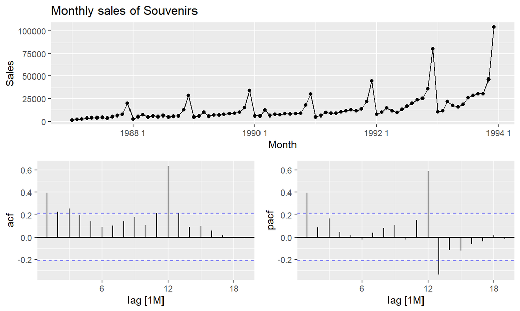

```r
souvenirs %>%
  gg_tsdisplay(Sales, plot_type='partial') +
  labs(title = "Monthly sales of Souvenirs")
```

## 정상성과 차분 예제

```r
souvenirs %>%
  features(Sales, unitroot_kpss)
```

```
$  # A tibble: 1 x 2
$    kpss_stat kpss_pvalue
$        <dbl>       <dbl>
$  1      1.31        0.01
```

KPSS 검정을 수행하였음. 귀무가설이 p-value가 0.01로 기각되어 해당 데이터는 차분을 요함.

## 정상성과 차분 예제

```r
souvenirs %>%
  features(Sales, unitroot_nsdiffs)
```

```
$  # A tibble: 1 x 1
$    nsdiffs
$      <int>
$  1       1
```

해당 데이터에서 계절성이 보여 `unitroot_nsdiffs()`를 사용하여 계절차분을 얼마나 요하는지 구함

## 정상성과 차분 예제

```r
souvenirs %>%
  features(Sales, unitroot_ndiffs)
```

```
$  # A tibble: 1 x 1
$    ndiffs
$     <int>
$  1      1
```

`unitroot_ndiffs()`를 사용하여 차분을 얼마나 요하는지 구함

## 정상성과 차분 예제

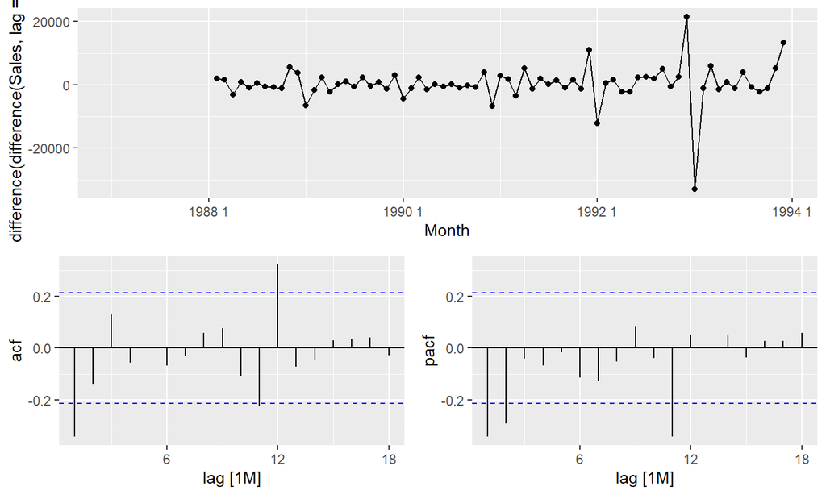

```r
souvenirs %>%
  gg_tsdisplay(difference(difference(Sales,lag = 12)), plot_type='partial')
```

시계열 그래프와 ACF 플롯을 통해해 정상성을 띠는 것을 볼 수 있었고,

## 정상성과 차분 예제

```r
souvenirs %>%
  features(difference(difference(Sales,lag = 12)),
           unitroot_kpss)
```

```
$  # A tibble: 1 x 2
$    kpss_stat kpss_pvalue
$        <dbl>       <dbl>
$  1     0.111         0.1
```

다시 수행한 KPSS 검정을 통해 귀무가설 기각에 실패하여 정상성을 띰을 확인할 수 있었음

## 후방이동 기호(Backshift notation)

후방이동(Backshift) 연산자 \(B\)는 시계열 시차를 다룰 때 유용함

\[ B y_{t} = y_{t - 1} \: . \]

후방이동 연산자를 사용하여 1차 차분을 다음과 같이 나타낼 수 있음

\[ y'_{t} = y_{t} - y_{t-1} = y_t - By_{t} = (1 - B)y_{t}\: . \]

여기서 1차 차분을 \((1-B)\)로 나타낸 것을 응용하여 2차 차분을 다음과 같이 나타냄

\[ y''_{t} = y_{t} - 2y_{t - 1} + y_{t - 2} = (1-2B+B^2)y_t = (1 - B)^{2} y_{t}\: . \]

따라서 일반적으로 \(d\)차 차분은 다음과 같음

\[ (1 - B)^{d} y_{t}. \]

## 후방이동 기호(Backshift notation)

### 후방이동 연산자 특징

- 차분을 연산자로 결합하면 보통의 대수 법칙을 사용하여 다룰 수 있음
- 특히, \(B\)를 포함하는 항은 서로 곱할 수 있음

이를 활용하여 1차 차분 이후의 계절성 차분은 다음과 같이 나타낼 수 있음

\[ \begin{align*} (1-B)(1-B^m)y_t &= (1 - B - B^m + B^{m+1})y_t \\ &= y_t-y_{t-1}-y_{t-m}+y_{t-m-1}, \end{align*} \]

## 자기회귀 모델 (Autoregressive models)

## 자기회귀 모델(Autoregressive models)

### 자기회귀 모델

**변수 자신의 과거 값**의 **선형 조합**을 이용하여 관심변수(variable of interest)를 예측

차수 \(p\)의 자기회귀 모델은 다음과 같이 쓸 수 있음

\[ y_{t} = c + \phi_{1}y_{t-1} + \phi_{2}y_{t-2} + \dots + \phi_{p}y_{t-p} + \varepsilon_{t}, \] 여기에서 \(\varepsilon_t\)는 백색잡음이며, 위 식을 **AR(\(p\))** 모델이라고 함

- AR(\(p\))모델은 다양한 종류의 시계열 패턴을 유연하게 표현 가능
- 파라미터 값\(\phi_1,\dots,\phi_p\)를 조정하면 다른 패턴이 나옴
- 오차항 \(\varepsilon_t\)의 분산은 시계열 패턴과 관련이 없으며 scale만 바꿈

## 자기회귀 모델(Autoregressive models)

정상성을 나타내는 자기회귀의 경우에는 몇몇 제한조건이 붙음

- AR(1) 모델의 경우:  
  \(-1 < \phi_1 < 1\).
- AR(2) 모델의 경우:  
  \(-1 < \phi_2 < 1\), \(\phi_1+\phi_2 < 1\), \(\phi_2-\phi_1 < 1\).
- \(p\ge3\)일 때, 제한조건이 더 복잡하나, `fable`이 알아서 해결함

[figure not shown]

Nifty `fable`

## 자기회귀 모델 - 예제

다음과 같은 R 코드로 \(\phi_{1} = 0.6\), \(\sigma^2=1\)이며 과정이 \(y_1=0\)부터 시작하는 AR(1) 모델을 생성

```r
y <- numeric(100)
e <- rnorm(100)
for(i in 2:100)
  y[i] <- 0.6*y[i-1] + e[i]
sim <- tsibble(idx = seq_len(100), y = y, index = idx)
head(sim,2)
```

```
$  # A tsibble: 2 x 2 [1]
$      idx     y
$    <int> <dbl>
$  1     1  0
$  2     2  1.25
```

## 자기회귀 모델 - 예제

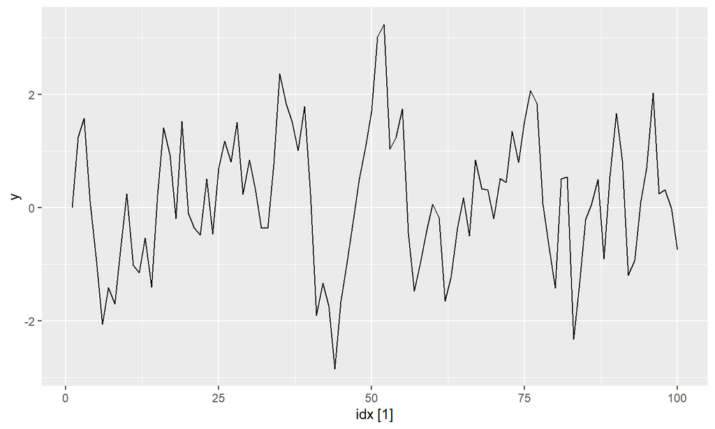

```r
sim %>%
  autoplot(y)
```

## 자기회귀 모델 - 예제

\(\phi_{1} = 0\)일 때

```r
y <- numeric(100)
e <- rnorm(100)
for(i in 2:100)
  y[i] <- 0*y[i-1] + e[i]
sim <- tsibble(idx = seq_len(100), y = y, index = idx)
head(sim,2)
```

```
$  # A tsibble: 2 x 2 [1]
$      idx     y
$    <int> <dbl>
$  1     1 0
$  2     2 0.754
```

## 자기회귀 모델 - 예제

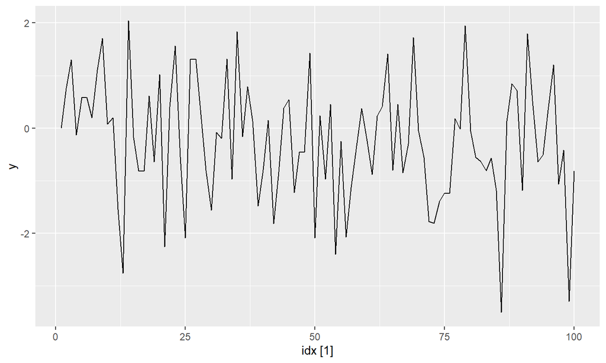

```r
sim %>%
  autoplot(y)
```

\(\phi_{1}\)가 0에 가까울 수록 백색소음

## 자기회귀 모델 - 예제

\(\phi_{1} = 1\)일 때

```r
y <- numeric(100)
e <- rnorm(100)
for(i in 2:100)
  y[i] <- 1*y[i-1] + e[i]
sim <- tsibble(idx = seq_len(100), y = y, index = idx)
head(sim,2)
```

```
$  # A tsibble: 2 x 2 [1]
$      idx     y
$    <int> <dbl>
$  1     1 0
$  2     2 0.818
```

## 자기회귀 모델 - 예제

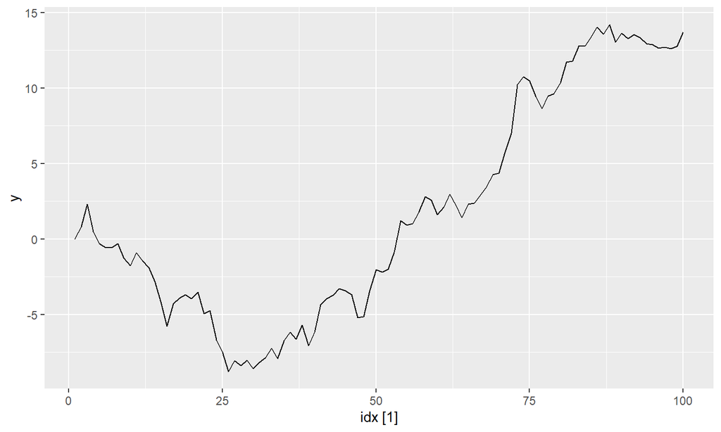

```r
sim %>%
  autoplot(y)
```

\(\phi_{1}\)가 1에 가까울 수록 Randomwalk 모델에 근접함을 보인다다

## 이동평균 모델 (Moving average models)

## 이동평균 모델(Moving average models)

이동평균 모델은 회귀형식 모델에서 과거 예측 오차(forecast error)를 이용함

차수 \(q\)의 이동평균 모델은 다음과 같이 쓸 수 있음

\[ y_{t} = c + \varepsilon_t + \theta_{1}\varepsilon_{t-1} + \theta_{2}\varepsilon_{t-2} + \dots + \theta_{q}\varepsilon_{t-q}, \] 여기서 \(\varepsilon_t\)는 백색잡음이며 위 모델을 **MA(\(q\))** 모델이라 함

- \(\varepsilon_t\)의 값을 관찰하지 않아, 보통 회귀식은 아님
- MA 파라미터에 제한조건을 도입하면 **가역(invertible)**이 성립함

## 이동평균 모델(Moving average models)

MA(1) 과정을 AR(\(\infty\))로 나타내어, **가장 최근의 오차는 현재와 과거 관측값의 선형 함수로 쓸 수 있음**:

\[ e_t = \sum_{j=0}^\infty (-\theta)^j y_{t-j}. \]

### 가역적 MA 모델

- \(|\theta| > 1\)일 때, 시차에 대한 가중치가 증가함  
  더 멀리 떨어진 관측치일수록 현재 오차에 영향력이 커짐
- \(|\theta|=1\)일 때, 멀리 떨어진 관측치와 최근의 관측치가 같은 영향을 미침
- \(|\theta|<1\)일 때, **가장 최근 관측값이 멀리 떨어진 관측값보다 큰 영향**

따라서, **\(|\theta|<1\)일 때, 과정은 가역적임임**

## 가역적 MA 모델

\[ \tag{MA(1)} y_t = -\theta_1\varepsilon_{t-1} + \varepsilon_t \] \[ y_t = (1-\theta_1B)\varepsilon_t \] \[ \frac{y_t}{1-\theta_1B}= \varepsilon_t \] \[ \because \sum\limits_{n=1}^{\infty}ar^{n-1} = \frac{a}{1-r} \quad (a\ne0,\,-1<r<1)\\ \] \[ \sum\limits_{n=1}^{\infty}y_t(\theta_1B)^{n-1} = \varepsilon_t\\ \]

## 가역적 MA 모델

\[ (1+\theta_1B+\theta_1^2B^2+\cdots+\theta_1^{n-1}B^{n-1})y_t= \varepsilon_t\\ \] \[ \tag{AR(∞)} y_t=-\theta_1y_{t-1}-\theta_1^2y_{t-2}+\cdots+\varepsilon_t\\ \]

## 이동평균 모델(Moving average models)

타 모델에 대해 가역성 제한조건은 정상성 제한조건과 비슷함

- MA(1) 모델의 경우:  
  \(-1<\theta_1<1\).
- MA(2) 모델의 경우:  
  \(-1<\theta_2<1,~\) \(\theta_2+\theta_1 >-1,~\) \(\theta_1 -\theta_2 < 1\).
- \(q\ge3\)일 때, 제한조건이 더 복잡하나, `fable`이 알아서 해결함

[figure not shown]

Nifty `fable`

## 비-계절성 ARIMA 모델 (Non-seasonal ARIMA models)

## 비-계절성 ARIMA 모델

비-계절성(non-seasonal) ARIMA 모델은 **차분**을 구하는 것을 **자기회귀**와 **이동평균 모델**과 결합한 것임.

- ARIMA는 AutoRegressive Integrated Moving Average의 약자
- integration 차분의 반대 의미

모델을 다음과 같이 나타낼 수 있음.

\[ \begin{equation} y'_{t} = c + \phi_{1}y'_{t-1} + \cdots + \phi_{p}y'_{t-p} + \theta_{1}\varepsilon_{t-1} + \cdots + \theta_{q}\varepsilon_{t-q} + \varepsilon_{t} \end{equation} \] 여기서 \(y'_{t}\)는 차분을 구한 시계열, 우변의 예측변수(predictor)에는 \(y_{t}\)의 시차 값과 시차 오차(lagged error)를 포함함. 위 모델을 **ARIMA(\(p, d, q\))** 모델이라고 함

## 비-계절성 ARIMA 모델

**ARIMA(\(p, d, q\))** 모델에서 각 변수 \(p, d, q\)는 다음과 같은 의미를 가짐

| \(p=\) 자기회귀 부분의 차수; |
| --- |
| \(d=\) 1차 차분이 포함된 정도; |
| \(q=\) 이동 평균 부분의 차수. |

ARIMA 모델 또한 후방이동 기호를 사용하면 다음과 같이 나타낼 수 있음

\[ \begin{equation} \begin{array}{c c c c} (1-\phi_1B - \cdots - \phi_p B^p) & (1-B)^d y_{t} &= &c + (1 + \theta_1 B + \cdots + \theta_q B^q)\varepsilon_t\\ {\uparrow} & {\uparrow} & &{\uparrow}\\ \text{AR($p$)} & \text{$d$ differences} & & \text{MA($q$)}\\ \end{array} \end{equation} \]

## ACF와 PACF그래프

적절한 \(p\)와 \(q\)값을 결정하기 위해서는 ACF와 PACF 그래프를 이용해야 함

차분을 구한 데이터가 다음 패턴을 띠면 ARIMA(\(p\),\(d\),0) 모델을 따름

- ACF가 지수적으로 감소하거나 사인 함수 모양인 경우;
- PACF그래프에서 시차 \(p\)에 막대가 유의미하게 존재하나, 시차 \(p\) 이후에는 없을 때.

차분을 구한 데이터가 다음 패턴을 띠면, 데이터는 ARIMA(0,\(d\),\(q\)) 모델을 따름

- PACF가 지수적으로 감소하거나 사인 함수 모양인 경우;
- ACF그래프에서 시차 \(q\)에 막대가 유의미하게 존재하나, 시차 \(q\) 이후에는 없을 때.

## 정보 기준(Information Criteria)

회귀에서 예측변수(predictor)를 고를 때 유용한 Akaike 정보 기준(AIC)은 ARIMA 모델에서 차수를 결정할 때도 유용

\[ \text{AIC} = -2 \log(L) + 2(p+q+k+1), \] ARIMA 모델에 대해 수정된 AIC(AICc)는 다음과 같음

\[ \text{AICc} = \text{AIC} + \frac{2(p+q+k+1)(p+q+k+2)}{T-p-q-k-2}, \]

이러한 AIC, AICc를 최소화하여 좋은 모델을 얻을 수 있음.

다만, \(d\)를 고를 때는 도움이 되지 않으므로 \(d\)를 고르기 위해서는 다른 방법 필요

## `fable`에서 ARIMA 모델링

## `fable`에서 ARIMA 모델링

`fable`의 `ARIMA` 함수는 변형된 힌드만-칸다카르(Hyndman-Khandakar) 알고리즘을 사용함

ARIMA모델을 얻기 위해 단위근 검정과 MLE 및 AICc최소화를 통합하여 사용

- KPSS 검정을 통한 차분값 도출
- AICc 최소화를 통한 최적의 \(p,q\) 값 도출

## 모델링 절차

ARIMA 모델을 (비-계절성) 시계열 데이터 모음에 맞출 때, 다음과 같은 과정은 유용한 일반적인 접근 방식이 될 수 있음

힌드만-칸다카르(Hyndman-Khandakar) 알고리즘은 다음의 3–5 단계만 처리함. 따라서 해당 알고리즘을 사용하더라도, 여전히 직접 나머지 단계를 처리해야함.

## 모델링 절차

1. 데이터를 그래프로 나타내고, 특이한 관측값을 찾는다.
2. 필요하다면, 분산을 안정화하기 위해 (Box-Cox 변환을 사용하여) 데이터를 변환한다.
3. 데이터가 정상성을 나타내지 않는다면, 데이터가 정상성을 나타낼 때까지 데이터를 가지고 1차 차분을 계산한다.
4. ACF/PACF 살펴보기: ARIMA(\(p\),\(d\),0) 혹은 ARIMA(0,\(d\),\(q\)) 모델 중 어느 것이 가장 적절한가?
5. 선택한 모델을 시도해보고, 더 나은 모델을 찾기 위해 AICc를 이용한다.
6. 잔차의 ACF를 그리고 잔차의 포트맨토(portmanteau) 검정을 하여 선택한 모델에서 잔차를 확인한다. 백색잡음 같이 보이지 않는다면, 수정된 모델을 사용한다.
7. 잔차가 백색잡음처럼 보이면, 예측값을 계산한다.

## `fable`에서 ARIMA 모델링 - 예제

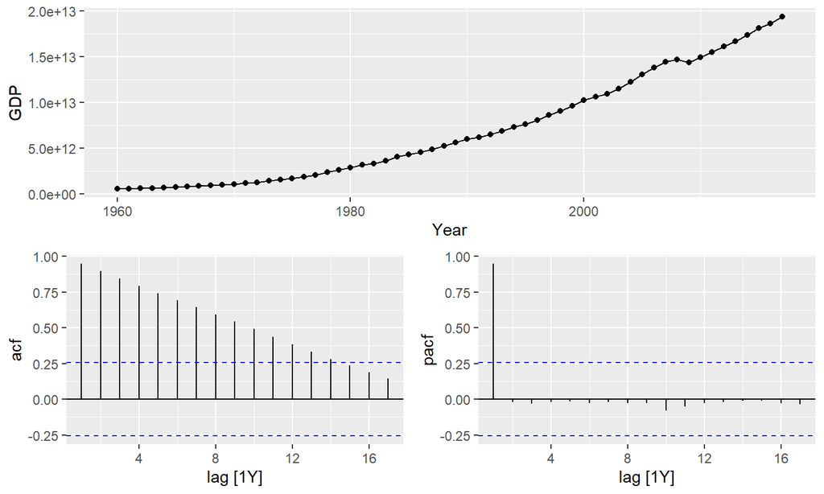

```r
global_economy %>%
  filter(Country == "United States") %>%
  gg_tsdisplay(GDP, plot_type='partial')
```

## `fable`에서 ARIMA 모델링 - 예제

```r
### 차분 얼마나
global_economy %>%
  filter(Country == "United States") %>%
  features(GDP, unitroot_ndiffs)
```

```
$  # A tibble: 1 x 2
$    Country       ndiffs
$    <fct>          <int>
$  1 United States      2
```

## `fable`에서 ARIMA 모델링 - 예제

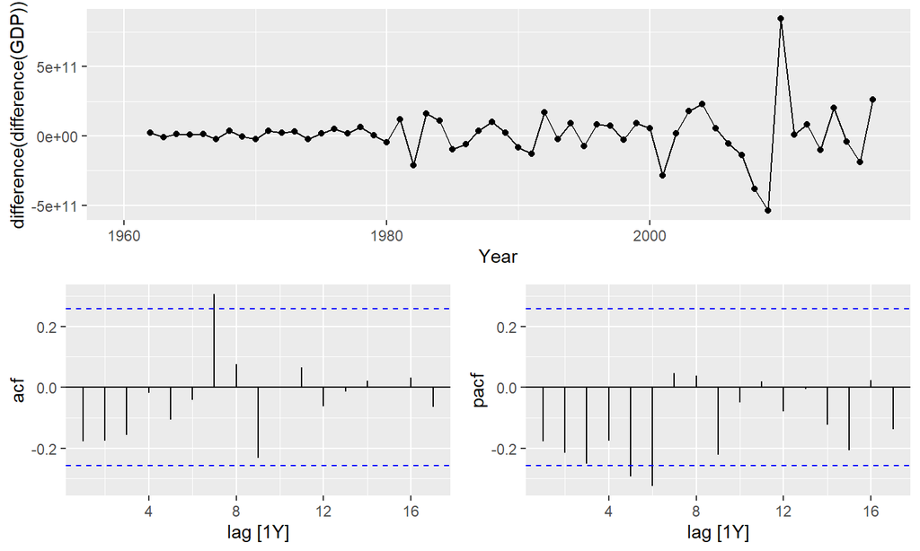

```r
global_economy %>%
  filter(Country == "United States") %>%
  gg_tsdisplay(difference(difference(GDP)), plot_type='partial')
```

## `fable`에서 ARIMA 모델링 - 예제

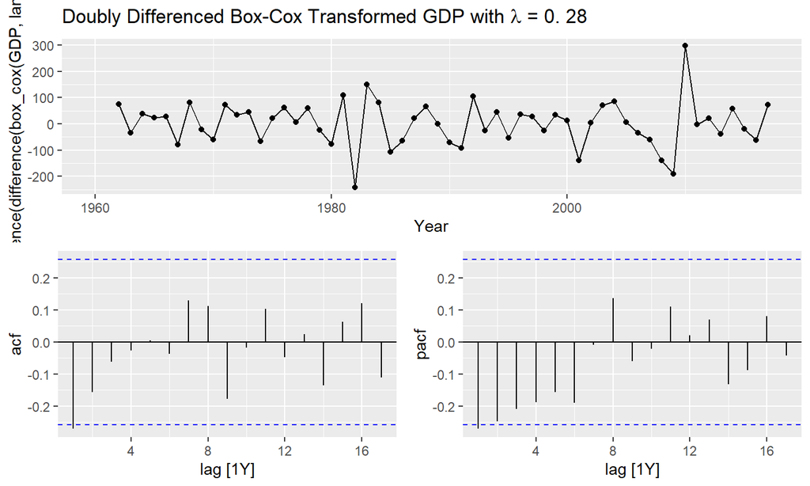

```r
global_economy %>% filter(Country == "United States") %>%
  gg_tsdisplay(difference(difference(box_cox(GDP, lambda))), plot_type='partial') +
  labs(title = latex2exp::TeX(paste0(
         "Doubly Differenced Box-Cox Transformed GDP with $\\lambda$ = ",
         round(lambda,2))))
```

## `fable`에서 ARIMA 모델링 - 예제

```r
q8_fit <- global_economy %>%
  filter(Country == "United States") %>%
  model(arima120 = ARIMA(box_cox(GDP, lambda) ~ pdq(1,2,0)),
        stepwise = ARIMA(box_cox(GDP, lambda)),
        search = ARIMA(box_cox(GDP, lambda), stepwise=FALSE))
```

## `fable`에서 ARIMA 모델링 - 예제

```r
q8_fit %>% select(search) %>% report()
```

```
$  Series: GDP
$  Model: ARIMA(1,1,0) w/ drift
$  Transformation: box_cox(GDP, lambda)
$
$  Coefficients:
$           ar1  constant
$        0.4586  118.1822
$  s.e.  0.1198    9.5047
$
$  sigma^2 estimated as 5479:  log likelihood=-325.32
$  AIC=656.65   AICc=657.1   BIC=662.78
```

## `fable`에서 ARIMA 모델링 - 예제

```r
q8_fit %>% select(arima120) %>% report()
```

```
$  Series: GDP
$  Model: ARIMA(1,2,0)
$  Transformation: box_cox(GDP, lambda)
$
$  Coefficients:
$            ar1
$        -0.2732
$  s.e.   0.1289
$
$  sigma^2 estimated as 6780:  log likelihood=-325.99
$  AIC=655.99   AICc=656.22   BIC=660.04
```

## `fable`에서 ARIMA 모델링 - 예제

```r
q8_fit %>%
  select(arima120) %>%
  report()
```

```
$  Series: GDP
$  Model: ARIMA(1,2,0)
$  Transformation: box_cox(GDP, lambda)
$
$  Coefficients:
$            ar1
$        -0.2732
$  s.e.   0.1289
$
$  sigma^2 estimated as 6780:  log likelihood=-325.99
$  AIC=655.99   AICc=656.22   BIC=660.04
```

## `fable`에서 ARIMA 모델링 - 예제

```r
augment(q8_fit) %>%
  filter(.model=='arima120') %>%
  features(.innov, ljung_box, lag = 10, dof = 1) #df = p+q
```

```
$  # A tibble: 1 x 4
$    Country       .model   lb_stat lb_pvalue
$    <fct>         <chr>      <dbl>     <dbl>
$  1 United States arima120    10.9     0.283
```

## `fable`에서 ARIMA 모델링 - 예제

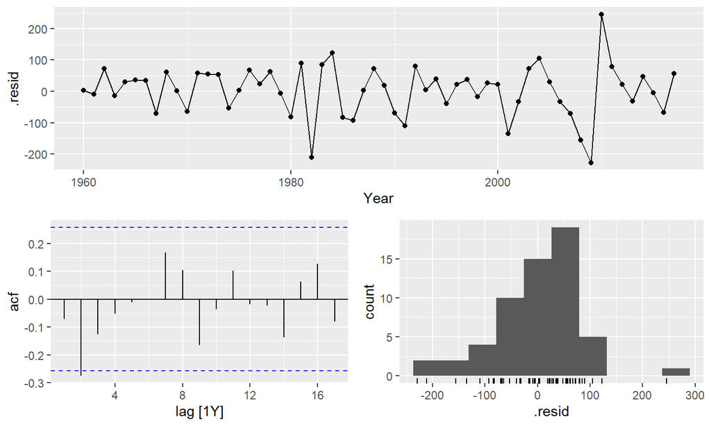

```r
q8_fit %>%
  select(arima120) %>%
  gg_tsresiduals()
```

## `fable`에서 ARIMA 모델링 - 예제

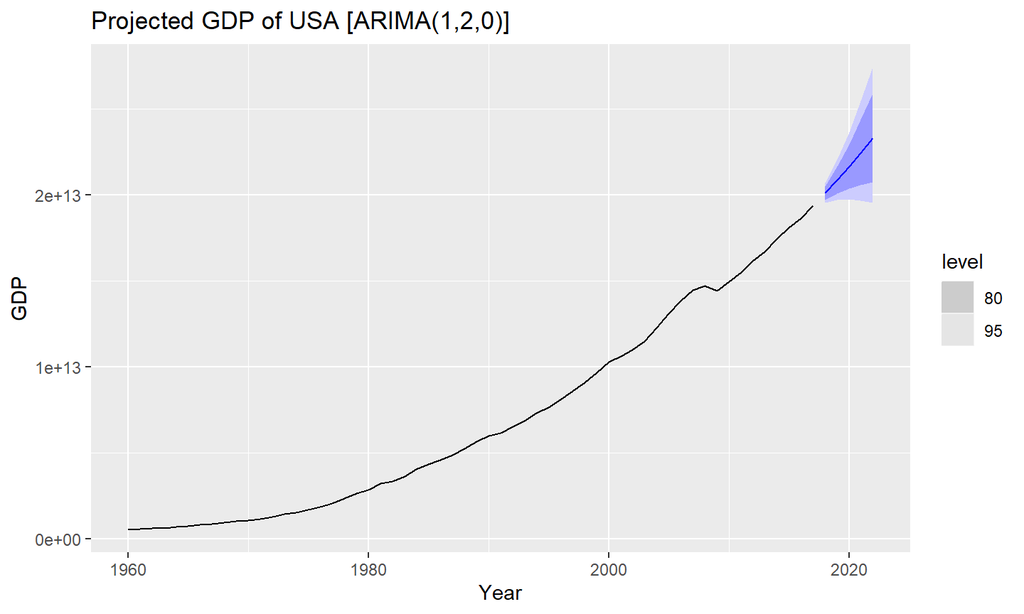

```r
q8_fit%>% forecast(h=5) %>% filter(.model=='arima120') %>%
  autoplot(global_economy) +
  labs(y = "GDP", title = "Projected GDP of USA [ARIMA(1,2,0)]")
```

## 계절성 ARIMA 모델 (Seasonal ARIMA models)

## 계절성 ARIMA 모델

ARIMA 모델을 이용하여 비-계절성 뿐만 아니라 다양한 종류의 **계절성(seasonal)** 데이터를 모델링 할 수 있음

계절성 ARIMA 모델은 기존 ARIMA 모델에 추가적인 **계절성 항**을 포함하여 구성되며 계절성 ARIMA 모델을 다음과 같이 나타냄

\[ \begin{equation} \begin{array}{c c c} \text{ARIMA} & \underbrace{(p, d, q)} & \underbrace{(P, D, Q)_{m}}\\ & {\uparrow} &{\uparrow}\\ & \text{Non-seasonal part} & \text{Seasonal part}\\ & \text{of the model} & \text{of the model}\\ \end{array} \end{equation} \] 여기서 \(m\)은 계절 주기임(seasonal period).

## 계절성 ARIMA 모델

AR이나 MA 모델의 계절성 부분은 PACF와 ACF의 **계절성 시차(\(m\))**에서 볼 수 있음

예를 들어 ARIMA(0,0,0)(0,0,1)\(_{12}\) 모델은 다음과 같을 것이다.

- ACF에 시차 12에 위치한 막대는 있지만 다른 유의미한 막대는 없는 모습;
- PACF의 계절성 시차가 지수적으로 감소하는 모습(즉, 시차 12, 24, 36, …에서).

비슷하게, ARIMA(0,0,0)(1,0,0)\(_{12}\) 모델은 다음과 같은 모습을 나타낼 것이다:

- ACF의 계절성 시차가 지수적으로 감소하는 모습;
- PACF의 시차 12에서 나타나는 유의미한 막대가 있는 모습.

계절성 ARIMA 모델에서 적절한 계절성 차수를 고려할 때, 계절성 시차를 고려하는 것에 주의

모델링 과정은 모델의 **비-계절성 성분과 계절성 AR과 MA 항을 골라야 하는 것**을 제외하고는 비-계절성 데이터에 대한 경우와 거의 같음

## 계절성 ARIMA 모델 - 예제

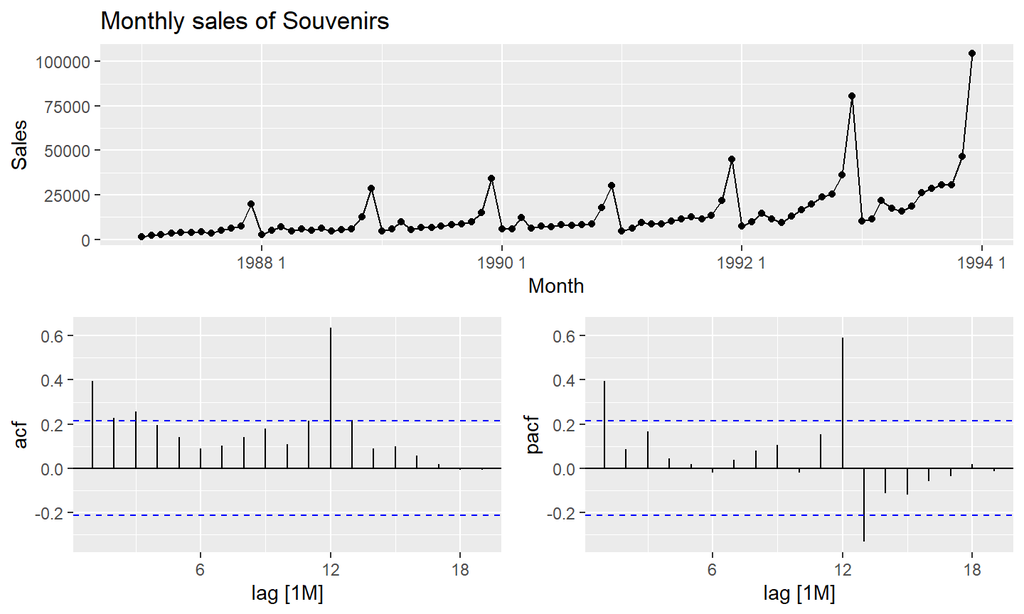

```r
souvenirs %>%
  gg_tsdisplay(Sales, plot_type='partial') +
  labs(title = "Monthly sales of Souvenirs")
```

## 계절성 ARIMA 모델 - 예제

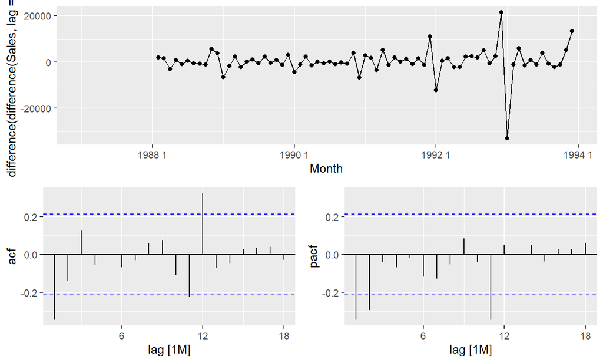

```r
souvenirs %>%
  gg_tsdisplay(difference(difference(Sales,lag = 12)), plot_type='partial')
```

## 계절성 ARIMA 모델 - 예제

```r
fit <- souvenirs %>%
  model(
    arima112111 = ARIMA(Sales ~ pdq(1,1,2) + PDQ(1,1,1)),
    arima112011 = ARIMA(Sales ~ pdq(1,1,2) + PDQ(0,1,1)),
    auto = ARIMA(Sales, stepwise = FALSE, approx = FALSE)
  )
```

## 계절성 ARIMA 모델 - 예제

```r
fit %>%
  select(arima112111) %>%
  report()
```

```
$  Series: Sales
$  Model: ARIMA(1,1,2)(1,1,1)[12]
$
$  Coefficients:
$           ar1      ma1      ma2   sar1    sma1
$        0.0051  -0.6639  -0.1823  0.022  0.7051
$  s.e.     NaN   0.0747   0.0125    NaN  0.0752
$
$  sigma^2 estimated as 16987893:  log likelihood=-693.84
$  AIC=1399.69   AICc=1401   BIC=1413.26
```

## 계절성 ARIMA 모델 - 예제

```r
fit %>%
  select(arima112011) %>%
  report()
```

```
$  Series: Sales
$  Model: ARIMA(1,1,2)(0,1,1)[12]
$
$  Coefficients:
$           ar1      ma1     ma2    sma1
$        0.5606  -1.2387  0.2872  0.7696
$  s.e.  0.4302   0.4687  0.4074  0.1925
$
$  sigma^2 estimated as 16161998:  log likelihood=-693.52
$  AIC=1397.03   AICc=1397.96   BIC=1408.35
```

## 계절성 ARIMA 모델 - 예제

```r
fit %>%
  select(auto) %>%
  report()
```

```
$  Series: Sales
$  Model: ARIMA(1,1,1)(0,1,1)[12]
$
$  Coefficients:
$           ar1      ma1    sma1
$        0.2401  -0.9013  0.7499
$  s.e.  0.1427   0.0709  0.1790
$
$  sigma^2 estimated as 16146440:  log likelihood=-693.69
$  AIC=1395.38   AICc=1395.98   BIC=1404.43
```

## 계절성 ARIMA 모델 - 예제

```r
augment(fit) %>%
  filter(.model=='auto') %>%
  features(.innov, ljung_box, lag = 17, dof = 3) #df = p+q , 84/5=16.8
```

```
$  # A tibble: 1 x 3
$    .model lb_stat lb_pvalue
$    <chr>    <dbl>     <dbl>
$  1 auto      6.68     0.946
```

The result is not significant (i.e., the \(p\) -value is relatively large). Thus, we can conclude that the residuals are not distinguishable from a white noise series.

## 계절성 ARIMA 모델 - 예제

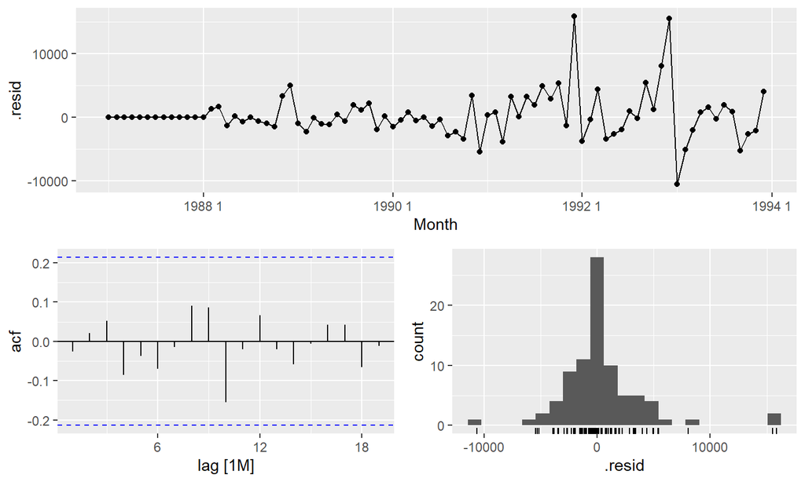

```r
fit %>%
  select(auto) %>%
  gg_tsresiduals()
```

## 계절성 ARIMA 모델 - 예제

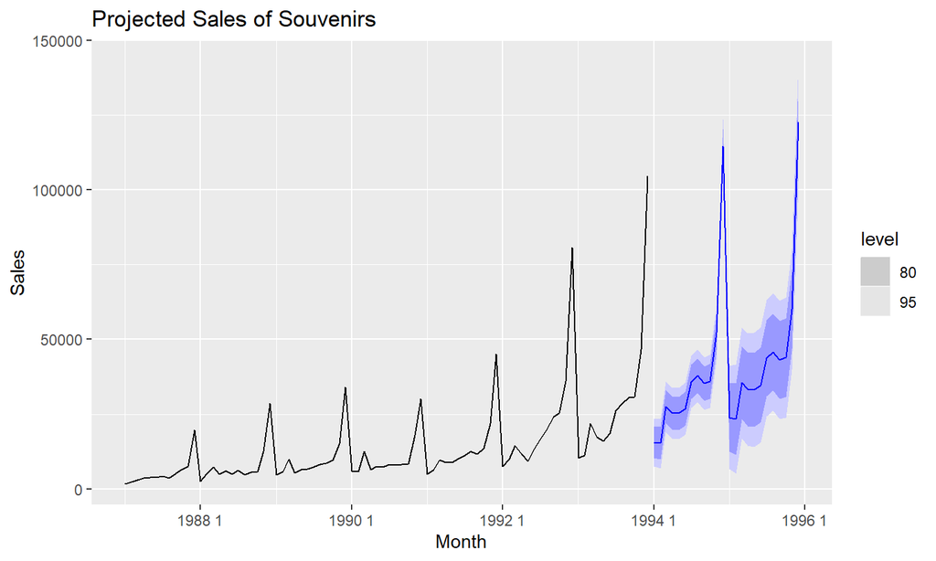

```r
fit %>% forecast() %>% filter(.model=='auto') %>%
  autoplot(souvenirs) +
  labs(y = "Sales", title = "Projected Sales of Souvenirs")
```

## Wrapup

제가 준비한 부분은 여기까지입니다.  
감사합니다